# Exploratory analysis of C2D data

# Objectives

This file contains an exploratory analysis of the c2d dataset with a view to probing its usefulness for our research. There are at least two ways in which the c2d data can enrich our current work.

1. *Identify critical referendum cases:* One of the LIDD objectives is to map the limits of DD in terms of the clash between popular sovereignty and the rule of law (esp. broader limits set by norms of international law). Therefore, it is of interest to identify the scale of the potential clash and this can be done by examining all referendums. As a cut-off point we choose the year 1990 across the C.o.E states. It is a symbolic date that marks the democratization wave of post-Soviet successor states and CEEC states belonging to the C.oE. How many potential instances are we dealing with? What was the outcome in these cases?
2. *Enrich the data app:* It would be good to enrich the current data APP with referendum event data. Data regarding referendum events that can be linked to our working LIDD typology is of particular value. Evidently, it will be impossible to find third-party datasets that exactly map onto the LIDD typology since our typology is new and hopefully goes beyond what is already out there. Nonetheless, enrichment is certainly possible.

# Summary

My basic conclusion is that the c2d can partly address the two objectives above, especially (2). We can quite easily enrich the app with more data that maps onto a simpler 3-fold LIDD typology with little effort.

The c2d data also offers some valuable shortcuts for identifying LIDD critical cases, point (1) above. It is not perfect in this regard, and some extra work will be required on our part. Elements of that work are unavoidable. We need a LIDD typology of what I would call critical LIDD cases, i.e., those types of cases that bring to the fore the potential clash between popular sovereignty and the rule of law. How can we identify such referendum events? The good news is that I think the c2d coding of referendum events can help quite a lot in this regard. But we will need to go a bit further if we want an operational LIDD typology of critical cases.

# The data

Excluding Switzerland’s 282 referendums the distribution looks like this.

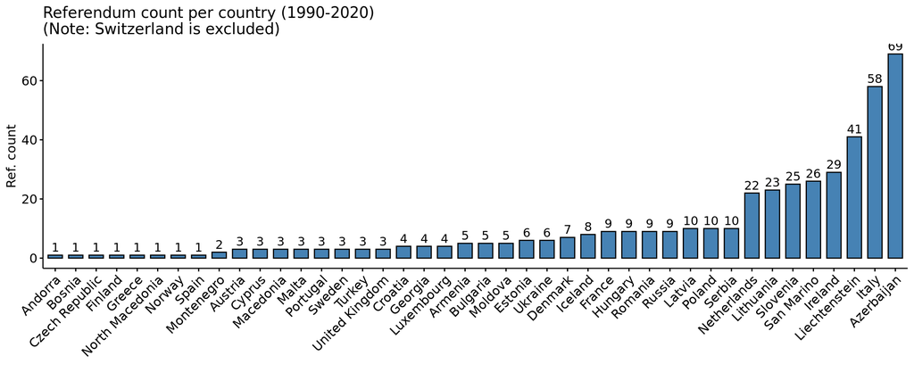

The count of referendums actually appears to be quite stable over the past 30 years (excluding Siwtzerland). The almost 450 referendums are relatively evenly spread at around 150 each decade, as shown in the second graph below.

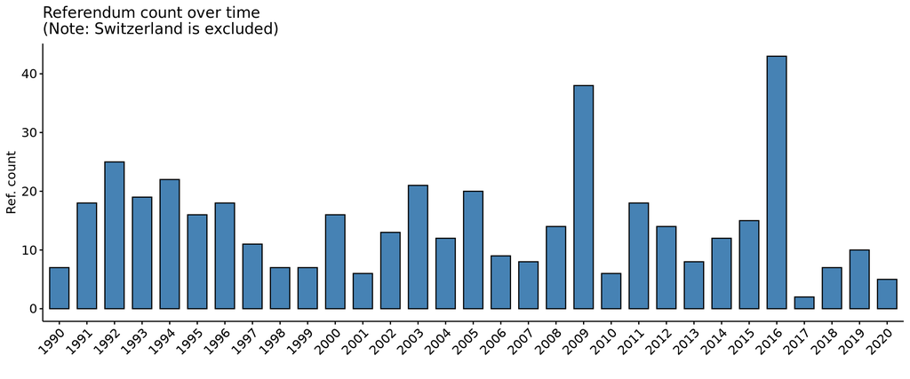

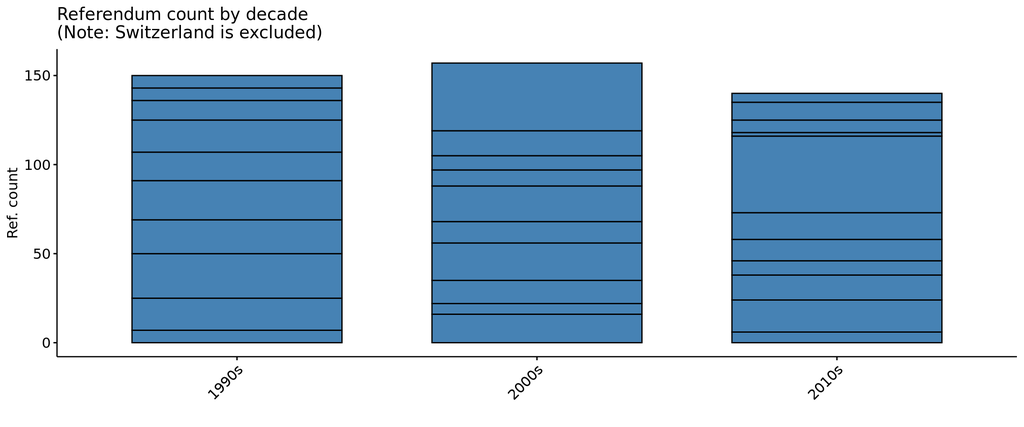

There is, however, some double counting in the data. For instance, the UK has had 2 referendums, one on changing the electoral system and the other case being the Brexit referendum. However, because C2D dichotomizes the vote into a YES/NO they transform the Brexit vote option into two votes: Remain (YES versus NO) and Leave (Yes versus NO). Another case is Cyprus, while the Republic of Cyprus has had one vote on the Anan reunification plan, the occupied Northern part has also had two votes. There could be others, for instance a multi-option referendum, say with options A, B or C would get transformed into 3 yes/no votes.

To get a fair picture of the distribution it’s a good idea to take out some of the outliers. I’d leave out Switzerland and Azerbaijan for now. In the case of Azerbaijan, it has only had 6 referendum events. The latest one on a 2016 constitutional reform included 29 questions, i.e., separate constitutional amendments. To avoid distortions to the analysis, I’ll put these two special cases in the annex.

With our two special cases exclusion, the total count of referendums is 378. The median count of referendums remains the same 5 (which shows why it’s a good metric to use).

- `institution`: This refers to the particular institution or instrument of direct democracy, what they call: citizen’s initiative, governmental referendum, mandatory referendum, optional referendum and counter proposal.
- `vote_trigger`: Three seemingly self-explanatory categories are provided: Automatic, Bottom-up and Top-down.
- `vote_trigger_actor`: This category includes actors such as Government, Parliament, Constitution and some others.
- `hierarchy_legal_norm`: This category includes Constitution, Laws, Ordinances, Treaties etc., though there seem to be lots of missing categories.

# C2D additional variables

We can take a look at these additional variables. Again, the data excludes the two special cases.

### Distribution of institutions (DD instruments)

| institution | n | percent |
| --- | --- | --- |
| Citizens’ initiative | 68 | 18.0 |
| Counter proposal | 1 | 0.3 |
| Governmental referendum | 134 | 35.4 |
| Mandatory referendum | 62 | 16.4 |
| Not provided | 13 | 3.4 |
| Optional referendum | 100 | 26.5 |

We can see that there are 13 missing observations, referred to as “Not provided”. These would need to be checked.

### Distribution of vote_trigger (a broad category of initiator)

| vote_trigger | n | percent |
| --- | --- | --- |
| Automatic | 74 | 19.6 |
| Bottom up | 162 | 42.9 |
| Top down | 142 | 37.6 |

Everything seems more or less in order for the `vote_trigger` variable. We can check that our intuition about the `institution` and the `vote_trigger` variables are broadly correct.

| institution | Automatic | Bottom up | Top down |
| --- | --- | --- | --- |
| Citizens’ initiative | NA | 66 | 2 |
| Counter proposal | NA | NA | 1 |
| Governmental referendum | 2 | NA | 132 |
| Mandatory referendum | 61 | NA | 1 |
| Not provided | 11 | NA | 2 |
| Optional referendum | NA | 96 | 4 |

On the whole the cross-table makes sense, although there are few observations that could be mistakes. For instance, 2 citizen’s initiatives are coded as Top Down, which is strange. While 4 optional referendums are also coded as Top Down. These few instances would need to be checked. Nonetheless, on the whole the instruments and type of initiator seem to tally.

### Distribution of hierarchy_legal_norm (the type of law)

While the `hierarchy_legal_norm` seems a useful variable in principle, it appears that over 40 percent of the data for this variable is missing or undefined.

| hierarchy_legal_norm | n | percent |
| --- | --- | --- |
| Constitution | 94 | 24.9 |
| International treaty | 3 | 0.8 |
| Law | 122 | 32.3 |
| Treaty | 1 | 0.3 |
| Undefined | 15 | 4.0 |
| NA | 143 | 37.8 |

We can check a random sample of 5 referendums that had missing codes and 5 that were undefined.

### Sample of 5 missing codes

| country | year | title.en |
| --- | --- | --- |
| Netherlands | 2005 | Treaty establishing a Constitution for Europe |
| Bulgaria | 2016 | Introduction of a majority voting system |
| Macedonia | 1991 | Independence |
| Latvia | 1991 | Independence |
| Moldova | 1994 | Preservation of independence |

### Sample of 5 coded as undefined

| country | year | title.en |
| --- | --- | --- |
| Romania | 2007 | Referendum on the impeachment of President Basescu |
| Denmark | 2000 | Introduction of the common Currency (Euro) |
| Romania | 2019 | Prohibition of emergency ordinances in the field of criminal law |
| Poland | 2015 | Benefit of the doubt in tax law for the taxpayer |
| Denmark | 2014 | Accession to European Unified Patent Court (UPC) |

Probably this variable could be fixed. The missing/undefined observations don’t seem particularly obscure. Should we want such a variable, it would need a clear definition and then a check.

# Referendum topic

The c2d data has a very useful extra variable, which is called a tag. It is essentially a coding of the referendum topic, basically what type of policy issue the vote was on. They provide up to 3 tags for a given referendum. I have split these into `tagA`, `tagB` and `tagC`.

The tags operate at different levels of granularity. So, tagA is the highest level and tagC the most detailed level.

We can take a random sample of 10 referendums to explore this coding system.

### Random sample of 10 referendum event tags

| country | year | title.en | tagA | tagB | tagC |
| --- | --- | --- | --- | --- | --- |
| Austria | 2013 | Future of the army: professional military | Security policy | Army | Military organisation |
| Italy | 2005 | Abolition of the restrictions on embryonic implantation and of the recognition of the embryo as participant | Education and research | Research | Genetic engineering |
| Hungary | 2008 | Abolition of tuition fees for higher public education | Education and research | Education policy | NA |
| Liechtenstein | 1992 | Abolition of the 8% threshold for parliamentary elections | State organisation | Political system | Electoral system |
| Netherlands | 1994 | National status - Option B: Status aparte (autonomy) | State organisation | National identity | NA |
| Liechtenstein | 2000 | Law on citizenship - introduction of faciliated naturalization for long-time residents | State organisation | Legal system | Citizenship |
| Slovenia | 2012 | Family Code | State organisation | Legal system | Fundamental rights |
| Slovenia | 2001 | Artificial insemination for unmarried women | Social Policy | Health | Reproductive medicine |
| Moldova | 1999 | Assigning more powers to the president | State organisation | Institutions | Government |
| Lithuania | 1994 | Initiative Submission VI: Restoring the value of devalued assets belonging to the State | Economy | Economic policy | Structural policy |

Up to 3 tags are provided as shown in the table -although sometimes only 2 are given. A brief look at the tags suggest they are in principle useful for our project, and could save a lot of time.

Let’s look at the top 10 tagA (the highest level) in terms of actual numbers.

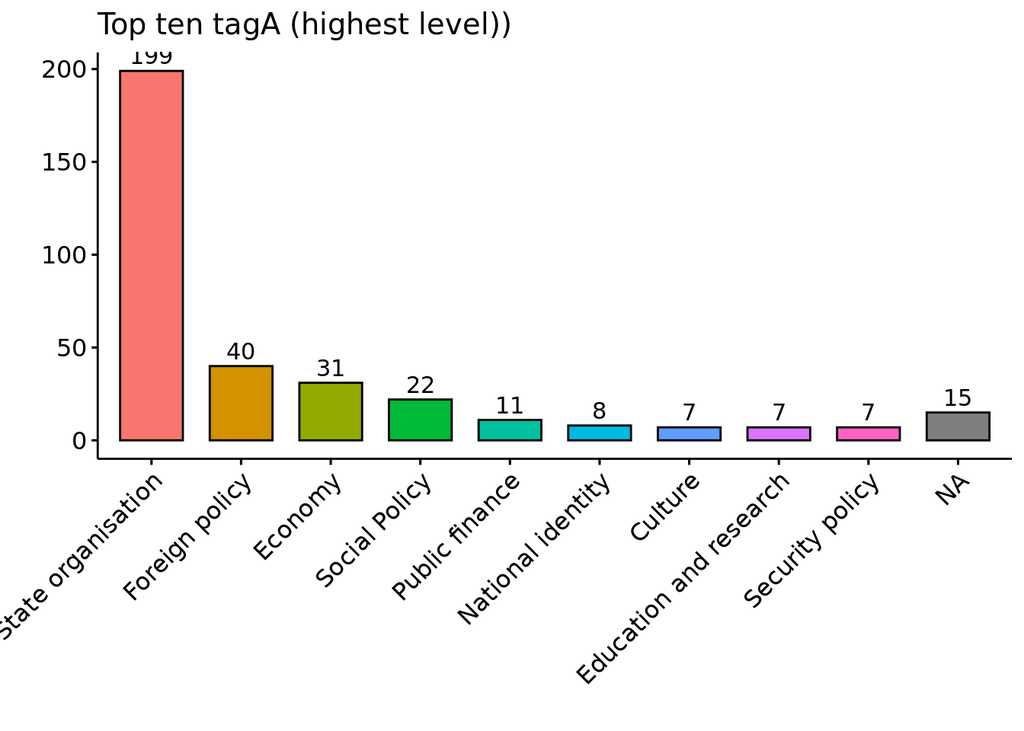

| country | year | title.en | title.de |
| --- | --- | --- | --- |
| France | 2001 | Re-opening of the Mont Blanc tunnel to trucks |  |
| Ireland | 2013 |  | Schaffung eines Appellationsgerichts |
| Ireland | 2013 |  | Abschaffung des Senats |
| Ireland | 2012 |  | Kinderrechte |
| Sweden | 2006 | Introduction of a new road toll system |  |
| Estonia | 1993 |  | Autonomie innerhalb Estlands |
| Estonia | 1993 |  | Autonomie innerhalb Estlands |
| Lithuania | 2012 | Parliamentary consultative plebiscite on the Building of a new nuclear power plant «Visaginas» | Bau eines neuen Kernkraftwerks |
| Bulgaria | 2013 |  | Bau eines neuen Kernkraftwerks |
| Romania | 2012 | Deposition of President Basescu | Absetzung von Staatspräsident Basescu |
| Liechtenstein | 2012 |  | Vermindertes Vetorecht des Fürsten |
| Serbia | 2006 | New constitution |  |
| Russia | 1994 |  | Beziehungen zur Ukraine mit Verträgen |
| San Marino | 2013 | Inflation correction until collective labor contract settlements are concluded | Teuerungsausgleich bis zum Abschluss eines Gesamtarbeitsvertrags |
| San Marino | 2013 | Accession negotiations with the European Union | Beitrittsverhandlungen mit der Europäischen Union |

### Examining the “Fundamental rights” tag

We can scan all the `Fundamental rights` tags provided at the three levels. This will give us some idea of both the tagging, i.e., the types of referendums tagged with the `Fundamental rights` attribute, and its relative prevalence. Evidently, there would be an increase in the number of cases if Switzerland and possibly Azerbaijan were added (see annex below).

| country | year | title.en |
| --- | --- | --- |
| Ireland | 1992 | Right to information relating to abortion and contraception |
| Ireland | 1992 | Freedom to travel for abortions abroad |
| Liechtenstein | 1992 | Codification of discrimination ban in the Constitution |
| Ireland | 2001 | Abolition of capital punishment |
| Ireland | 2002 | Protection of human life in pregnancy |
| Italy | 2003 | Abrogation of the obligation for estate owners to tolerate road rights for circuit lines |
| Slovenia | 2004 | Renewed residency rights for former minorities stemming from former Yugoslav autonomous republics |
| Liechtenstein | 2005 | Counterproposal to the initiative ‘For Life’ |
| Liechtenstein | 2005 | Initiative ‘For life’ |
| Latvia | 2012 | Russian as second official language |
| Slovenia | 2012 | Family Code |
| Ireland | 2018 | Regulation of termination of pregnancy |
| San Marino | 2019 | Prohibition of discrimination on the basis of sexual orientation |

Note there are some referendum events tagged as Fundamental rights that we would probably not consider to fall within our scope, such as the Italy 2003 referendum on road rights or perhaps the Latvian one on Russian language. There are also some missing cases that would fall within our scope of understanding fundamental rights such gay marriage.

If we scan the c2d data for the tag `Homosexuals`, the following cases in the table below can be identified. These would seem to fall within the LIDD conception.

### Cases related to the “Homosexuals” tag

| country | year | title.en |
| --- | --- | --- |
| Croatia | 2013 | Marriage defined as a union between a man and a woman only |
| Ireland | 2015 | Marriage for same-sax couples |
| Slovenia | 2015 | Introduction of same-sex marriage |
| Romania | 2018 | Marriage only between man and woman |

# Annex

This annex looks at the 2 special cases of Swtizerland and Azerbaijan. The former is obviously more relevant since Azerbaijan has been excluded because of its weird tendency to have referendum events on essentially the same topic, constitutional reform, that bundle up to 30 issues.

## Switzerland

### Distribution of institutions (DD instruments)

| institution | n | percent |
| --- | --- | --- |
| Citizens’ initiative | 123 | 43.6 |
| Counter proposal | 15 | 5.3 |
| Mandatory referendum | 51 | 18.1 |
| Optional referendum | 93 | 33.0 |

### Distribution of vote_trigger (a broad category of initiator)

| vote_trigger | n | percent |
| --- | --- | --- |
| Automatic | 49 | 17.4 |
| Bottom up | 216 | 76.6 |
| Top down | 16 | 5.7 |
| NA | 1 | 0.4 |

There seems to be coding error for the case that is missing (NA) on the `vote_trigger` attribute. Below we can check the cross-table to see whether the categories are consistent.

| institution | Automatic | Bottom up | Top down |
| --- | --- | --- | --- |
| Citizens’ initiative | NA | 122 | 1 |
| Counter proposal | NA | NA | 14 |
| Mandatory referendum | 49 | 1 | 1 |
| Optional referendum | NA | 93 | NA |

### Distribution of hierarchy_legal_norm (the type of law)

It seems that for Switzerland there are some additional elements in the ordering of the hierarchy.

| hierarchy_legal_norm | n | percent |
| --- | --- | --- |
| Constitution | 184 | 65.2 |
| Constitution / law / ordinance | 2 | 0.7 |
| Constitution / law / other | 25 | 8.9 |
| International treaty | 1 | 0.4 |
| Law | 64 | 22.7 |
| Treaty | 6 | 2.1 |

### Random sample of 10 Swiss referendum event tags

| country | year | title.en | tagA | tagB | tagC |
| --- | --- | --- | --- | --- | --- |
| Switzerland | 2000 | Citizen’s initiative “For the protection of people against manipulations in reproductive technology (initiative for humane reproduction)” | Reproductive medicine | Research | NA |
| Switzerland | 2018 | Citizens’ initiative “Swiss law instead of foreign judges (initiative for self-determination)”. | State organisation | Institutions | Courts |
| Switzerland | 1998 | Federal decree on a temporary new article in the Constitution on cereals | Crop production | NA | NA |
| Switzerland | 2005 | Amendment of 08 October 2004 to the Federal law on employment in industry, trade and commerce (Labour Law) | Employment conditions | NA | NA |
| Switzerland | 1994 | Federal law on use of Swiss troops in peace-keeping operations | UN | International deployment | NA |
| Switzerland | 1993 | Federal decree on temporary measures against rising costs of health insurance | Health and accident insurance | NA | NA |
| Switzerland | 1990 | Citizen’s initiative for a motorway-free zone between Murten and Yverdon | Road construction | Protection of nature and cultural heritage | NA |
| Switzerland | 2002 | Amendment to Swiss criminal code (abortion) | Criminal law | Status of women | NA |
| Switzerland | 2010 | Citizen’s initiative of 26 July 2007 “against the cruelty of animals and for better legal protection of animals”. | Animal protection | NA | NA |
| Switzerland | 2010 | Federal decree of 25 september 2009 on a constitutional article concerning the research on humans. | Research | Universities | NA |

### The Swiss “Fundamental rights” tag

| country | year | title.en |
| --- | --- | --- |
| Switzerland | 1991 | Federal decree on lowering the voting age to 18 |
| Switzerland | 1998 | Citizen’s initiative “Switzerland without police snooping” |
| Switzerland | 2002 | Citizen’s initiative “For mother and child - protection of the unborn child and assistance for mothers in need” |
| Switzerland | 2005 | Federal law of 18 June 2004 on the registration of partnerships of same-sex couples (Partnership law) |
| Switzerland | 2010 | Federal Decree of 10 june 2010 on the deporting of criminal foreigners (Counter-proposal) |
| Switzerland | 2010 | Citizens initiative “for the expulsion of criminal foreigners” (expulsion initiative) |
| Switzerland | 2016 | Federal law of 25 September 2015 on intelligence agencies (Intelligence Agencies Act, NDG) |
| Switzerland | 2016 | Citizens’ initiative of 29 December 2012 “For the enforcement of the deportation of criminal foreigners” |

### Swiss cases related to the “Homosexuals” tag

| country | year | title.en |
| --- | --- | --- |
| Switzerland | 2005 | Federal law of 18 June 2004 on the registration of partnerships of same-sex couples (Partnership law) |

## Azerbaijan

There is not much point delving into the Azerbaijan case. The list of referendums and tags should be sufficient at this point.

| date | year | title.en | tagA | tagB | tagC |
| --- | --- | --- | --- | --- | --- |
| 2016-09-26 | 2016 | Organisation of the armed forces | Security policy | Army | Military organisation |
| 2016-09-26 | 2016 | Protection of human dignity | State organisation | Legal system | Fundamental rights |
| 2016-09-26 | 2016 | Rights of people with disabilities | Legal system | Persons with disabilities | Fundamental rights |
| 2016-09-26 | 2016 | Restriction of private property | Fundamental rights | Soil | Land law |
| 2016-09-26 | 2016 | Data protection | State organisation | Legal system | Data protection |
| 2016-09-26 | 2016 | Lock out in industrial disputes | Economy | Employment | Fundamental rights |
| 2016-09-26 | 2016 | Extended ban on creating unrest | Security policy | Legal system | Criminal law |
| 2016-09-26 | 2016 | Extended assembly ban | Security policy | Citizens’ rights | Fundamental rights |
| 2016-09-26 | 2016 | Deprivation of citizenship | State organisation | Legal system | Citizenship |
| 2016-09-26 | 2016 | Extended limitation of the right to stand as a candidate | State organisation | Citizens’ rights | Voting rights |
| 2016-09-26 | 2016 | Right of action only for individual military personnel | Army | Armed forces - general | Courts |
| 2016-09-26 | 2016 | Stricter ban on overturns | Security policy | Legal system | Criminal law |
| 2016-09-26 | 2016 | Health protection in labour law | Employment | Employment conditions | Health |
| 2016-09-26 | 2016 | Legal protection in administrative procedure | State organisation | Legal system | Fundamental rights |
| 2016-09-26 | 2016 | Protection from arbitrariness | State organisation | Legal system | Fundamental rights |
| 2016-09-26 | 2016 | Principle of proportionality | State organisation | Legal system | Fundamental rights |
| 2016-09-26 | 2016 | Abolition of the minimum age for Members of Parliament | Institutions | Parliament | Voting rights |
| 2016-09-26 | 2016 | Loss of office of deputies for unethical behavior | State organisation | Institutions | Parliament |
| 2016-09-26 | 2016 | Dissolution of the National Assembly | State organisation | Institutions | Parliament |
| 2016-09-26 | 2016 | Abolition of the minimum age for the President | State organisation | Institutions | Government |
| 2016-09-26 | 2016 | Seven instead of five years term of office for Presidents | State organisation | Institutions | Government |
| 2016-09-26 | 2016 | Introduction of Vice-Presidents | State organisation | Institutions | Government |
| 2016-09-26 | 2016 | Takeover of office by the Vice-Presidents | State organisation | Institutions | Government |
| 2016-09-26 | 2016 | Immunity of the President and the Vice-Presidents | State organisation | Institutions | Government |
| 2016-09-26 | 2016 | Remuneration and protection of the First Vice-President | State organisation | Institutions | Government |
| 2016-09-26 | 2016 | Signature of international treaties by Vice-Presidents | State organisation | Institutions | Government |
| 2016-09-26 | 2016 | Requirements for cabinet members | State organisation | Institutions | Government |
| 2016-09-26 | 2016 | Abolition of the minimum age for judges | State organisation | Institutions | Courts |
| 2016-09-26 | 2016 | Liability of the municipalities | State organisation | Legal system | Fundamental rights |
| 2009-03-18 | 2009 | Constitutional reform (publication of normative legal Acts) | State organisation | Legal system | Fundamental rights |
| 2009-03-18 | 2009 | Constitutional reform (restrictions on independence of municipalities) | State organisation | Federalism | Division of tasks |
| 2009-03-18 | 2009 | Constitutional reform (publication of Supreme Court decisions) | State organisation | Legal system | Fundamental rights |
| 2009-03-18 | 2009 | Constitutional reform (publication of Constitutional Court decisions) | State organisation | Legal system | Fundamental rights |
| 2009-03-18 | 2009 | Constitutional reform (court decisions) | State organisation | Institutions | Courts |
| 2009-03-18 | 2009 | Constitutional reform (aim of court proceedings to discover the truth) | State organisation | Institutions | Courts |
| 2009-03-18 | 2009 | Constitutional reform (renaming of the Administration of the President, distinguishing between interstate and intergovernmental agreements) | State organisation | Institutions | Government |
| 2009-03-18 | 2009 | Constitutional reform (security of the President) | State organisation | Institutions | Government |
| 2009-03-18 | 2009 | Constitutional reform (presidential election in time of war) | State organisation | Institutions | Government |
| 2009-03-18 | 2009 | Constitutional reform (right of citizen’s initiative) | State organisation | Citizens’ rights | Citizen’s initiatives |
| 2009-03-18 | 2009 | Constitutional reform (intergovernmental agreements, publication of municipal reports) | State organisation | Federalism | Intergovernmental relations |
| 2009-03-18 | 2009 | Constitutional reform (organisation of parliamentary committees) | State organisation | Institutions | Parliament |
| 2009-03-18 | 2009 | Constitutional reform (assemblies of parliamentary sessions are open to the public) | State organisation | Institutions | Fundamental rights |
| 2009-03-18 | 2009 | Constitutional reform (elections of the Milli Majlis in times of war) | State organisation | Institutions | Parliament |
| 2009-03-18 | 2009 | Constitutional reform (liability for expressing disrespect of State symbols) | State organisation | Legal system | Criminal law |
| 2009-03-18 | 2009 | Constitutional reform (citizen’s duties) | State organisation | Legal system | Citizenship |
| 2009-03-18 | 2009 | Constitutional reform (human and civil rights and freedoms) | State organisation | Legal system | Fundamental rights |
| 2009-03-18 | 2009 | Constitutional reform (rights of accused) | State organisation | Legal system | Fundamental rights |
| 2009-03-18 | 2009 | Constitutional reform (freedom of information) | State organisation | Legal system | Fundamental rights |
| 2009-03-18 | 2009 | Constitutional reform (cannot be forced to express or demonstrate religious belief) | State organisation | Legal system | Fundamental rights |
| 2009-03-18 | 2009 | Constitutional reform (protection of the environment) | Environment and living space | Environment | Environmental policy |
| 2009-03-18 | 2009 | Constitutional reform (îndividual and family privacy, access to personal data) | State organisation | Legal system | Fundamental rights |
| 2009-03-18 | 2009 | Constitutional reform (prohibition of expropriation of private property for public needs) | State organisation | Legal system | Fundamental rights |
| 2009-03-18 | 2009 | Constitutional reform (right to equality in relation to privileges) | State organisation | Legal system | Fundamental rights |
| 2009-03-18 | 2009 | Constitutional reform (renaming the National Bank of Azerbaijan the Central Bank of Azerbaijan) | State organisation | Institutions | National bank |
| 2009-03-18 | 2009 | Constitutional reform (ban of ‘religious movements’ and religions that humiliate human dignity and contradict principles of humanity) | Culture | religion and media | Religion - churches |
| 2009-03-18 | 2009 | Constitutional reform (protection of rights of children) | State organisation | Legal system | Fundamental rights |
| 2009-03-18 | 2009 | Constitutional reform (guarantee that economic development be socially oriented) | Social Policy | NA | NA |
| 2009-03-18 | 2009 | Constitutional reform (decent living conditions for all citizens) | Social Policy | Social groups | NA |
| 2002-08-24 | 2002 | Constitutional amendments in regard to accession to the Council of Europe | State organisation | Political system | Constitution |
| 2002-08-24 | 2002 | Constitutional amendment to be consistent with the European Convention on the Protection of Human Rights (ECHR) | State organisation | Political system | Constitution |
| 2002-08-24 | 2002 | Various constitutional amendments | State organisation | Political system | Constitution |
| 2002-08-24 | 2002 | Constitutional amendment for judicial reform | State organisation | Institutions | Courts |
| 2002-08-24 | 2002 | Constitutional amendments on the organisation of Parliament and Government | State organisation | Institutions | NA |
| 2002-08-24 | 2002 | Constitutional amendment on electoral procedure for presidential elections | State organisation | Political system | Electoral system |
| 2002-08-24 | 2002 | Constitutional amendment excluding certain issues from referendums | State organisation | Citizens’ rights | Referendum |
| 2002-08-24 | 2002 | Constitutional amendment on voting system for parliamentary elections | State organisation | Political system | Electoral system |
| 1995-11-12 | 1995 | Constitution | State organisation | Political system | Constitution |
| 1993-08-29 | 1993 | Confidence in President Elchibey | State organisation | Institutions | Government |
| 1991-12-29 | 1991 | Independence | State organisation | National identity | NA |